# Deep Neural Network for Image Classification

This notebook will demonstrate the process of using a deep neural network in R to perform image classification.

Necessary libraries:

```r
library(gdata)
library("jpeg")
library("imager")
```

We use the following function to load the images:

```r
getFileNameAndExtension <- function(file){
    ex <- strsplit(basename(file), split="\\.")
    ex<-unlist(ex)
    return(ex)
}
```

```r
firstVideoFileName<-'marker.mov'
secondVideoFileName<-'bottle.mov'
outFilePrefix='out'
outFileSuffix='.jpg'
thumbNailFolder<-"Small"
```

```r
nameAndExtension<-getFileNameAndExtension(firstVideoFileName)
fnames <- paste0(thumbNailFolder,nameAndExtension[[1]],"/","out", 2, ".jpg")
fnames
```

'Smallmarker/out2.jpg'

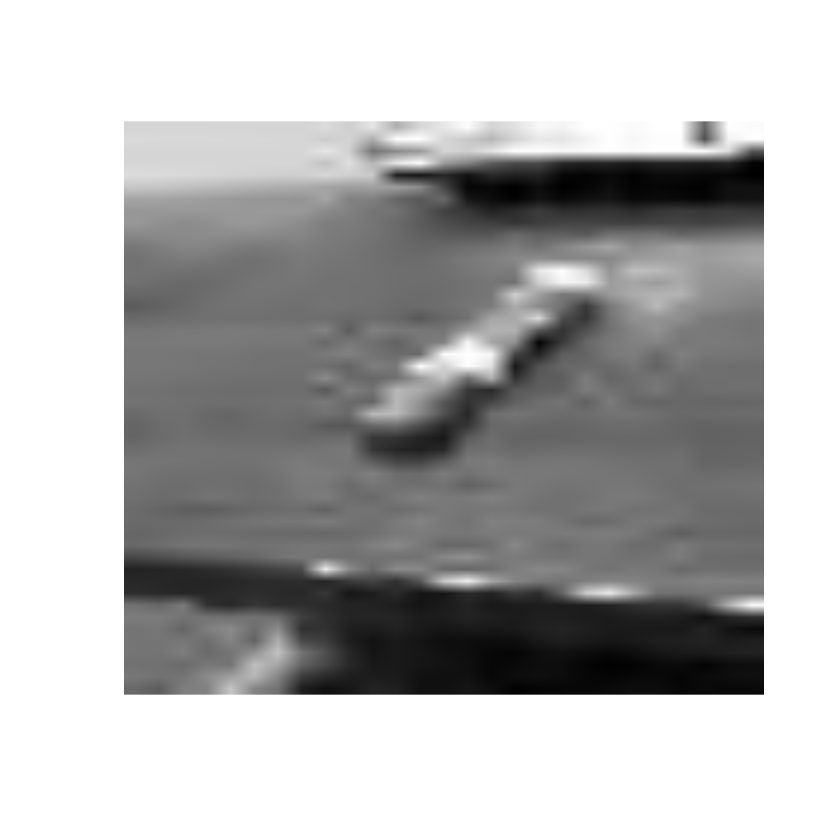

```r
sampleMarker<-readJPEG(fnames,native=TRUE)
plot(0:1,0:1,type="n",ann=FALSE,axes=FALSE)
rasterImage(sampleMarker,0,0,1,1)
```

```r
nameAndExtension<-getFileNameAndExtension(secondVideoFileName)
fnames <- paste0(thumbNailFolder,nameAndExtension[[1]],"/","out", 2, ".jpg")
fnames
```

'Smallbottle/out2.jpg'

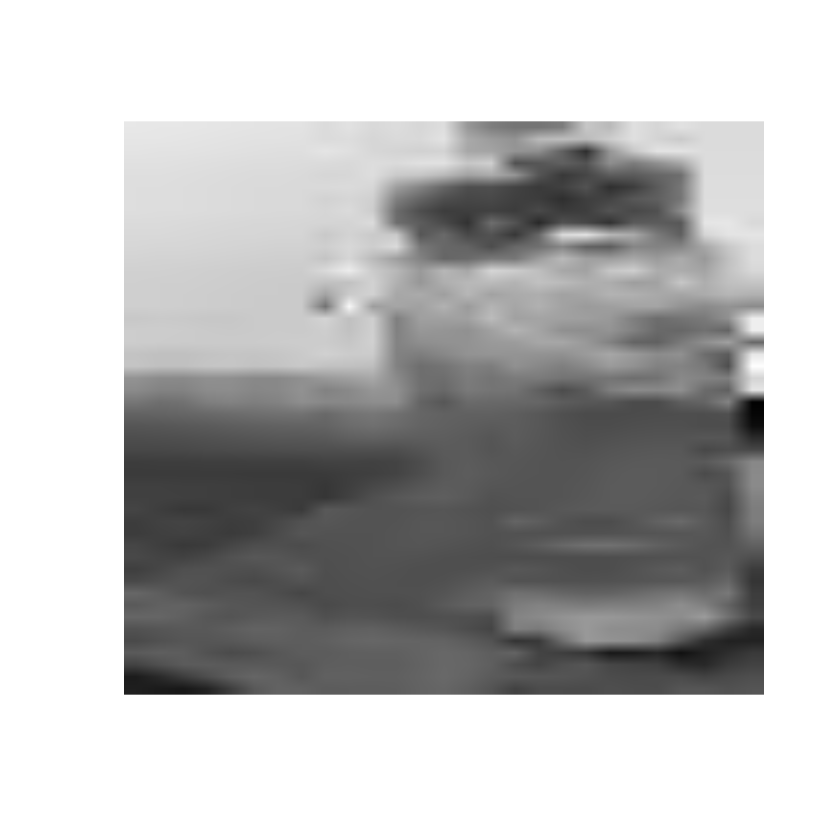

```r
sampleBottle<-readJPEG(fnames,native=TRUE)
plot(0:1,0:1,type="n",ann=FALSE,axes=FALSE)
rasterImage(sampleBottle,0,0,1,1)
```

We will use the grayscale intensity of each image as the feature input for a neural network.

```r
dim(sampleMarker)
```

1. 48

2. 27

```r
gs.matrix<-as.matrix(sampleMarker)
dim(gs.matrix)
```

1. 48

2. 27

```r
i.vector<-unmatrix(gs.matrix,byrow=T)
length(i.vector) # unmatrix the gray intensity image as a single column vector, which will be used as feature values to train neural network
```

1296

Next we label the images with the following function:

```r
loadImagesfromFolderAndLabel <- function(pathName,prefix, clasLabel) {
imageNames<-paste0(prefix,"*.*")
files<-list.files(path=pathName,pattern=imageNames,all.files=T,full.name=T,no..=T)
list_of_images=lapply(files,load.image)
#list_of_images=lapply(files,read.pnm)
#plot(list_of_images[[1]])
n.images<-length(list_of_images)
thmb.matrix<-as.matrix(list_of_images[[1]])
image.vector<-unmatrix(thmb.matrix,byrow=T)
for(ii in 2:n.images)
{
  thmb.matrix<-as.matrix(list_of_images[[ii]])
  i.vector<-unmatrix(thmb.matrix,byrow=T)
  image.vector<-rbind(image.vector,i.vector)
}
image.frame<-data.frame(image.vector)
n.rows<-nrow(image.frame)
class1.label<-rep(clasLabel,n.rows)
image.frame<-cbind(image.frame,class1.label)
rm(list_of_images)
return (image.frame)
}
```

We then create the input vectors:

```r
nameAndExtension<-getFileNameAndExtension(firstVideoFileName)
folderName<-paste0(thumbNailFolder,nameAndExtension[[1]])
folderName
```

'Smallmarker'

```r
class1.frame <- loadImagesfromFolderAndLabel(folderName,outFilePrefix,1)
dim(class1.frame)
```

1. 124

2. 1297

```r
nameAndExtension<-getFileNameAndExtension(secondVideoFileName)
folderName<-paste0(thumbNailFolder,nameAndExtension[[1]])
folderName
```

'Smallbottle'

```r
class2.frame <- loadImagesfromFolderAndLabel(folderName,outFilePrefix,-1)
dim(class2.frame)
```

1. 112

2. 1297

```r
total.frame<-rbind(class1.frame,class2.frame)
dim(total.frame)
```

1. 236

2. 1297

Then we create a training and test set, using 60% of the images for the training set and 40% for the test set:

```r
train.index<-sample(nrow(total.frame),nrow(total.frame)*0.6)
training.set<-total.frame[train.index,]
training.set
```

|  | r1.c1 | r1.c2 | r1.c3 | r1.c4 | r1.c5 | r1.c6 | r1.c7 | r1.c8 | r1.c9 | r1.c10 | ... | r27.c40 | r27.c41 | r27.c42 | r27.c43 | r27.c44 | r27.c45 | r27.c46 | r27.c47 | r27.c48 | class1.label |
| --- | --- | --- | --- | --- | --- | --- | --- | --- | --- | --- | --- | --- | --- | --- | --- | --- | --- | --- | --- | --- | --- |
| i.vector.57 | 0.8392157 | 0.8156863 | 0.8666667 | 0.8196078 | 0.8431373 | 0.8117647 | 0.6196078 | 0.6235294 | 0.5960784 | 0.5450980 | ... | 0.4627451 | 0.4039216 | 0.1254902 | 0.12156863 | 0.09803922 | 0.12156863 | 0.03529412 | 0.04705882 | 0.05882353 | 1 |
| i.vector.941 | 0.9019608 | 0.9019608 | 0.8941176 | 0.8862745 | 0.8784314 | 0.8745098 | 0.8666667 | 0.8666667 | 0.8784314 | 0.8431373 | ... | 0.2392157 | 0.2196078 | 0.2392157 | 0.25098039 | 0.27450980 | 0.30196078 | 0.27843137 | 0.25490196 | 0.27058824 | -1 |
| i.vector.961 | 0.9098039 | 0.9019608 | 0.8941176 | 0.8823529 | 0.8745098 | 0.8705882 | 0.8705882 | 0.8705882 | 0.8705882 | 0.8470588 | ... | 0.2352941 | 0.2274510 | 0.2392157 | 0.24313725 | 0.27058824 | 0.29803922 | 0.28235294 | 0.25882353 | 0.27058824 | -1 |
| i.vector.58 | 0.8274510 | 0.8313725 | 0.8470588 | 0.8352941 | 0.8470588 | 0.6392157 | 0.6431373 | 0.6196078 | 0.5843137 | 0.5333333 | ... | 0.4901961 | 0.2745098 | 0.1019608 | 0.10588235 | 0.10980392 | 0.14509804 | 0.03921569 | 0.07450980 | 0.05490196 | 1 |
| i.vector.421 | 0.9137255 | 0.9098039 | 0.9019608 | 0.8941176 | 0.8823529 | 0.8745098 | 0.8705882 | 0.8666667 | 0.8588235 | 0.8549020 | ... | 0.2980392 | 0.2627451 | 0.2470588 | 0.23137255 | 0.21960784 | 0.20392157 | 0.19607843 | 0.21176471 | 0.23921569 | -1 |
| i.vector.70 | 0.8666667 | 0.8431373 | 0.8392157 | 0.8352941 | 0.8705882 | 0.6627451 | 0.6392157 | 0.5843137 | 0.5647059 | 0.5254902 | ... | 0.4588235 | 0.2274510 | 0.1176471 | 0.09803922 | 0.12941176 | 0.09019608 | 0.05490196 | 0.05882353 | 0.05490196 | 1 |
| i.vector.681 | 0.9176471 | 0.9137255 | 0.9058824 | 0.8980392 | 0.8901961 | 0.8784314 | 0.8745098 | 0.8705882 | 0.8627451 | 0.8588235 | ... | 0.2509804 | 0.2156863 | 0.2274510 | 0.23529412 | 0.24313725 | 0.26666667 | 0.29019608 | 0.29411765 | 0.28235294 | -1 |
| i.vector.68 | 0.8470588 | 0.8588235 | 0.8431373 | 0.8549020 | 0.8745098 | 0.7882353 | 0.6627451 | 0.6313725 | 0.5686275 | 0.5333333 | ... | 0.4549020 | 0.2901961 | 0.1019608 | 0.13725490 | 0.09019608 | 0.11764706 | 0.04313725 | 0.04705882 | 0.04705882 | 1 |
| i.vector.761 | 0.9137255 | 0.9098039 | 0.9019608 | 0.8941176 | 0.8823529 | 0.8745098 | 0.8705882 | 0.8666667 | 0.8509804 | 0.8470588 | ... | 0.2549020 | 0.1960784 | 0.2235294 | 0.23529412 | 0.25490196 | 0.28235294 | 0.27450980 | 0.25490196 | 0.26666667 | -1 |
| i.vector.661 | 0.9176471 | 0.9137255 | 0.9058824 | 0.8980392 | 0.8901961 | 0.8784314 | 0.8745098 | 0.8705882 | 0.8705882 | 0.8666667 | ... | 0.2588235 | 0.2117647 | 0.2196078 | 0.22745098 | 0.26274510 | 0.30588235 | 0.29803922 | 0.27058824 | 0.28235294 | -1 |
| i.vector.109 | 0.8392157 | 0.8666667 | 0.8509804 | 0.8784314 | 0.8039216 | 0.6627451 | 0.6313725 | 0.6000000 | 0.5333333 | 0.4980392 | ... | 0.1529412 | 0.1176471 | 0.1137255 | 0.12156863 | 0.10588235 | 0.05490196 | 0.04313725 | 0.05882353 | 0.05882353 | 1 |
| i.vector.241 | 0.9137255 | 0.9098039 | 0.9019608 | 0.8941176 | 0.8823529 | 0.8745098 | 0.8705882 | 0.8666667 | 0.8823529 | 0.8470588 | ... | 0.2666667 | 0.2117647 | 0.2196078 | 0.23921569 | 0.26666667 | 0.28627451 | 0.29411765 | 0.28627451 | 0.27843137 | -1 |
| i.vector.411 | 0.9098039 | 0.9058824 | 0.8980392 | 0.8901961 | 0.8784314 | 0.8705882 | 0.8627451 | 0.8588235 | 0.8588235 | 0.8549020 | ... | 0.2980392 | 0.2509804 | 0.2235294 | 0.23529412 | 0.24313725 | 0.20784314 | 0.19607843 | 0.23921569 | 0.27450980 | -1 |
| i.vector.271 | 0.9176471 | 0.9137255 | 0.9058824 | 0.8980392 | 0.8901961 | 0.8784314 | 0.8745098 | 0.8705882 | 0.8627451 | 0.8588235 | ... | 0.2470588 | 0.2627451 | 0.2078431 | 0.22745098 | 0.27058824 | 0.27058824 | 0.28627451 | 0.29803922 | 0.25882353 | -1 |
| i.vector.104 | 0.8392157 | 0.8705882 | 0.8196078 | 0.8509804 | 0.8274510 | 0.6784314 | 0.6235294 | 0.6313725 | 0.5568627 | 0.5294118 | ... | 0.2039216 | 0.1098039 | 0.1058824 | 0.11764706 | 0.10588235 | 0.05490196 | 0.03921569 | 0.05490196 | 0.05098039 | 1 |
| i.vector.73 | 0.8392157 | 0.8392157 | 0.8549020 | 0.8470588 | 0.8588235 | 0.6470588 | 0.6431373 | 0.6117647 | 0.5803922 | 0.5019608 | ... | 0.4470588 | 0.2078431 | 0.1215686 | 0.10196078 | 0.13333333 | 0.10588235 | 0.06274510 | 0.05882353 | 0.07450980 | 1 |
| i.vector.75 | 0.8392157 | 0.8392157 | 0.8549020 | 0.8470588 | 0.8588235 | 0.6470588 | 0.6431373 | 0.6117647 | 0.5725490 | 0.5176471 | ... | 0.4078431 | 0.1882353 | 0.1254902 | 0.10588235 | 0.11764706 | 0.09411765 | 0.07058824 | 0.07058824 | 0.06274510 | 1 |
| i.vector.77 | 0.8352941 | 0.8352941 | 0.8470588 | 0.8392157 | 0.8549020 | 0.6470588 | 0.6509804 | 0.6235294 | 0.5568627 | 0.5176471 | ... | 0.6509804 | 0.1686275 | 0.1176471 | 0.11372549 | 0.12941176 | 0.10196078 | 0.07058824 | 0.06666667 | 0.06274510 | 1 |
| i.vector.831 | 0.9058824 | 0.9058824 | 0.8980392 | 0.8901961 | 0.8784314 | 0.8705882 | 0.8627451 | 0.8588235 | 0.8588235 | 0.8549020 | ... | 0.2470588 | 0.2313725 | 0.2352941 | 0.23529412 | 0.26274510 | 0.30196078 | 0.28627451 | 0.25490196 | 0.26274510 | -1 |
| i.vector.511 | 0.9176471 | 0.9137255 | 0.9058824 | 0.8980392 | 0.8901961 | 0.8784314 | 0.8745098 | 0.8705882 | 0.8588235 | 0.8549020 | ... | 0.2392157 | 0.2470588 | 0.2352941 | 0.21960784 | 0.22352941 | 0.25882353 | 0.29019608 | 0.28235294 | 0.25882353 | -1 |
| i.vector.1 | 0.8666667 | 0.8196078 | 0.8745098 | 0.7921569 | 0.6470588 | 0.6274510 | 0.5921569 | 0.5529412 | 0.5176471 | 0.4941176 | ... | 0.1254902 | 0.1058824 | 0.1215686 | 0.10980392 | 0.06274510 | 0.03529412 | 0.05098039 | 0.06274510 | 0.05490196 | 1 |
| i.vector.781 | 0.9137255 | 0.9098039 | 0.9019608 | 0.8941176 | 0.8823529 | 0.8745098 | 0.8705882 | 0.8666667 | 0.8588235 | 0.8549020 | ... | 0.2235294 | 0.2000000 | 0.2039216 | 0.25490196 | 0.24705882 | 0.27843137 | 0.29803922 | 0.24313725 | 0.28235294 | -1 |
| i.vector.4 | 0.8470588 | 0.8235294 | 0.8901961 | 0.7882353 | 0.6313725 | 0.6196078 | 0.5921569 | 0.5529412 | 0.5176471 | 0.4980392 | ... | 0.1176471 | 0.1019608 | 0.1372549 | 0.10980392 | 0.05490196 | 0.04313725 | 0.05098039 | 0.04705882 | 0.05490196 | 1 |
| i.vector.43 | 0.8352941 | 0.8431373 | 0.8196078 | 0.8627451 | 0.8039216 | 0.6549020 | 0.6196078 | 0.5882353 | 0.5803922 | 0.5372549 | ... | 0.9058824 | 0.1176471 | 0.1019608 | 0.11764706 | 0.11372549 | 0.06666667 | 0.03921569 | 0.05490196 | 0.06274510 | 1 |
| i.vector.2 | 0.8666667 | 0.8196078 | 0.8745098 | 0.7921569 | 0.6470588 | 0.6274510 | 0.5921569 | 0.5529412 | 0.5215686 | 0.4941176 | ... | 0.1058824 | 0.1058824 | 0.1254902 | 0.10980392 | 0.06274510 | 0.03529412 | 0.04705882 | 0.05882353 | 0.05098039 | 1 |
| i.vector.1071 | 0.9098039 | 0.9019608 | 0.8941176 | 0.8823529 | 0.8745098 | 0.8705882 | 0.8705882 | 0.8705882 | 0.8901961 | 0.8470588 | ... | 0.2352941 | 0.1882353 | 0.2313725 | 0.25098039 | 0.25490196 | 0.27843137 | 0.28235294 | 0.26666667 | 0.27450980 | -1 |
| i.vector.611 | 0.9098039 | 0.9058824 | 0.8980392 | 0.8941176 | 0.8862745 | 0.8784314 | 0.8745098 | 0.8705882 | 0.8666667 | 0.8549020 | ... | 0.2666667 | 0.2588235 | 0.2549020 | 0.26274510 | 0.27450980 | 0.27058824 | 0.27058824 | 0.29411765 | 0.32549020 | -1 |
| i.vector.701 | 0.9176471 | 0.9137255 | 0.9058824 | 0.8980392 | 0.8901961 | 0.8784314 | 0.8745098 | 0.8705882 | 0.8588235 | 0.8549020 | ... | 0.2627451 | 0.2078431 | 0.2274510 | 0.22745098 | 0.23529412 | 0.26274510 | 0.26274510 | 0.25882353 | 0.27843137 | -1 |
| i.vector.106 | 0.8352941 | 0.8627451 | 0.8274510 | 0.8666667 | 0.8235294 | 0.6705882 | 0.6313725 | 0.6235294 | 0.5568627 | 0.4980392 | ... | 0.2313725 | 0.1137255 | 0.1058824 | 0.11764706 | 0.10196078 | 0.05098039 | 0.03921569 | 0.05490196 | 0.05490196 | 1 |
| i.vector.119 | 0.8705882 | 0.8392157 | 0.8627451 | 0.8117647 | 0.6627451 | 0.6156863 | 0.6274510 | 0.5803922 | 0.5019608 | 0.4862745 | ... | 0.1176471 | 0.1058824 | 0.1215686 | 0.10980392 | 0.06274510 | 0.03529412 | 0.05098039 | 0.06274510 | 0.05490196 | 1 |
| ... | ... | ... | ... | ... | ... | ... | ... | ... | ... | ... |  | ... | ... | ... | ... | ... | ... | ... | ... | ... | ... |
| i.vector.441 | 0.9137255 | 0.9098039 | 0.9019608 | 0.8941176 | 0.8823529 | 0.8745098 | 0.8705882 | 0.8666667 | 0.8588235 | 0.8549020 | ... | 0.3019608 | 0.2352941 | 0.2588235 | 0.25098039 | 0.21176471 | 0.19215686 | 0.21568627 | 0.23921569 | 0.24313725 | -1 |
| i.vector.49 | 0.8352941 | 0.8470588 | 0.8470588 | 0.8588235 | 0.6509804 | 0.6392157 | 0.6000000 | 0.5803922 | 0.5411765 | 0.5098039 | ... | 0.6980392 | 0.1647059 | 0.1098039 | 0.11372549 | 0.11372549 | 0.06274510 | 0.05098039 | 0.07058824 | 0.05098039 | 1 |
| i.vector.44 | 0.8117647 | 0.8392157 | 0.8117647 | 0.8470588 | 0.7960784 | 0.6352941 | 0.5843137 | 0.5725490 | 0.5529412 | 0.5137255 | ... | 0.8705882 | 0.1254902 | 0.1176471 | 0.13333333 | 0.11764706 | 0.06274510 | 0.04705882 | 0.06274510 | 0.05490196 | 1 |
| i.vector.3 | 0.8509804 | 0.8156863 | 0.8823529 | 0.7921569 | 0.6352941 | 0.6117647 | 0.5843137 | 0.5568627 | 0.5176471 | 0.4901961 | ... | 0.1176471 | 0.1098039 | 0.1254902 | 0.11372549 | 0.06274510 | 0.03529412 | 0.04705882 | 0.05882353 | 0.05098039 | 1 |
| i.vector.12 | 0.8745098 | 0.8549020 | 0.8784314 | 0.8156863 | 0.6666667 | 0.6196078 | 0.6274510 | 0.5725490 | 0.5137255 | 0.4901961 | ... | 0.1294118 | 0.1058824 | 0.1254902 | 0.10980392 | 0.06274510 | 0.03529412 | 0.04705882 | 0.05882353 | 0.05098039 | 1 |
| i.vector.60 | 0.8470588 | 0.8470588 | 0.8588235 | 0.8470588 | 0.8588235 | 0.6431373 | 0.6352941 | 0.6039216 | 0.5843137 | 0.5176471 | ... | 0.4627451 | 0.2313725 | 0.1019608 | 0.10980392 | 0.09411765 | 0.13725490 | 0.03529412 | 0.06666667 | 0.05882353 | 1 |
| i.vector.521 | 0.9137255 | 0.9098039 | 0.9019608 | 0.8941176 | 0.8823529 | 0.8745098 | 0.8705882 | 0.8666667 | 0.8549020 | 0.8509804 | ... | 0.2235294 | 0.2431373 | 0.2392157 | 0.26666667 | 0.23137255 | 0.26274510 | 0.30588235 | 0.26274510 | 0.29411765 | -1 |
| i.vector.861 | 0.9019608 | 0.9019608 | 0.8941176 | 0.8862745 | 0.8784314 | 0.8745098 | 0.8666667 | 0.8666667 | 0.8666667 | 0.8509804 | ... | 0.2509804 | 0.2156863 | 0.2352941 | 0.23921569 | 0.26274510 | 0.30588235 | 0.30588235 | 0.28235294 | 0.28235294 | -1 |
| i.vector.81 | 0.8352941 | 0.8274510 | 0.8431373 | 0.8392157 | 0.8470588 | 0.6509804 | 0.6509804 | 0.5803922 | 0.5725490 | 0.5294118 | ... | 1.0000000 | 0.1215686 | 0.1098039 | 0.12156863 | 0.11764706 | 0.07058824 | 0.04313725 | 0.05882353 | 0.06666667 | 1 |
| i.vector.83 | 0.8392157 | 0.8666667 | 0.8352941 | 0.8705882 | 0.8196078 | 0.6588235 | 0.6117647 | 0.6000000 | 0.5725490 | 0.5215686 | ... | 0.8901961 | 0.1176471 | 0.1098039 | 0.11764706 | 0.10588235 | 0.06274510 | 0.05098039 | 0.06274510 | 0.05098039 | 1 |
| i.vector.91 | 0.8392157 | 0.8549020 | 0.8274510 | 0.8705882 | 0.8156863 | 0.6784314 | 0.6313725 | 0.5803922 | 0.5686275 | 0.5058824 | ... | 0.6745098 | 0.1098039 | 0.1058824 | 0.12156863 | 0.10980392 | 0.05882353 | 0.04705882 | 0.06274510 | 0.05882353 | 1 |
| i.vector.631 | 0.9176471 | 0.9137255 | 0.9019608 | 0.8941176 | 0.8862745 | 0.8823529 | 0.8784314 | 0.8784314 | 0.8588235 | 0.8588235 | ... | 0.2666667 | 0.2509804 | 0.2549020 | 0.26666667 | 0.27450980 | 0.28235294 | 0.28627451 | 0.29019608 | 0.29019608 | -1 |
| i.vector.531 | 0.9176471 | 0.9137255 | 0.9058824 | 0.8941176 | 0.8823529 | 0.8705882 | 0.8627451 | 0.8588235 | 0.8549020 | 0.8509804 | ... | 0.2274510 | 0.2039216 | 0.2156863 | 0.23529412 | 0.25882353 | 0.27450980 | 0.27843137 | 0.27843137 | 0.28235294 | -1 |
| i.vector.50 | 0.8549020 | 0.8588235 | 0.8509804 | 0.8588235 | 0.6470588 | 0.6352941 | 0.6039216 | 0.5882353 | 0.5372549 | 0.5137255 | ... | 0.6784314 | 0.1686275 | 0.1176471 | 0.11764706 | 0.12156863 | 0.06666667 | 0.05882353 | 0.07450980 | 0.05490196 | 1 |
| i.vector.113 | 0.8313725 | 0.8431373 | 0.8509804 | 0.8705882 | 0.6627451 | 0.6509804 | 0.6078431 | 0.5882353 | 0.5294118 | 0.5098039 | ... | 0.1921569 | 0.1019608 | 0.1098039 | 0.12156863 | 0.09411765 | 0.04705882 | 0.04705882 | 0.06274510 | 0.05490196 | 1 |
| i.vector.5 | 0.8627451 | 0.8470588 | 0.8980392 | 0.7843137 | 0.6431373 | 0.6235294 | 0.5882353 | 0.5686275 | 0.5176471 | 0.4941176 | ... | 0.1176471 | 0.1098039 | 0.1254902 | 0.11372549 | 0.06274510 | 0.03529412 | 0.04705882 | 0.05882353 | 0.05098039 | 1 |
| i.vector.35 | 0.8352941 | 0.8549020 | 0.8352941 | 0.8392157 | 0.8627451 | 0.7803922 | 0.6470588 | 0.5921569 | 0.5960784 | 0.5372549 | ... | 0.4509804 | 0.9921569 | 0.1882353 | 0.04313725 | 0.12156863 | 0.13333333 | 0.05490196 | 0.06274510 | 0.03529412 | 1 |
| i.vector.69 | 0.8470588 | 0.8392157 | 0.8470588 | 0.8431373 | 0.8705882 | 0.6627451 | 0.6509804 | 0.6117647 | 0.5686275 | 0.5294118 | ... | 0.4431373 | 0.2313725 | 0.1019608 | 0.12941176 | 0.10980392 | 0.13333333 | 0.03921569 | 0.08235294 | 0.05490196 | 1 |
| i.vector.64 | 0.8549020 | 0.8470588 | 0.8509804 | 0.8431373 | 0.8627451 | 0.6509804 | 0.6352941 | 0.5960784 | 0.5568627 | 0.5176471 | ... | 0.4823529 | 0.2156863 | 0.1254902 | 0.09803922 | 0.12549020 | 0.10588235 | 0.06274510 | 0.05098039 | 0.06274510 | 1 |
| i.vector.301 | 0.9176471 | 0.9137255 | 0.9058824 | 0.8941176 | 0.8823529 | 0.8705882 | 0.8627451 | 0.8588235 | 0.8549020 | 0.8509804 | ... | 0.2352941 | 0.2156863 | 0.2156863 | 0.23137255 | 0.26274510 | 0.27450980 | 0.25490196 | 0.23529412 | 0.22745098 | -1 |
| i.vector.401 | 0.9098039 | 0.9058824 | 0.8980392 | 0.8901961 | 0.8784314 | 0.8705882 | 0.8627451 | 0.8588235 | 0.8549020 | 0.8509804 | ... | 0.2823529 | 0.2431373 | 0.2156863 | 0.22352941 | 0.23529412 | 0.21176471 | 0.20784314 | 0.25098039 | 0.27843137 | -1 |
| i.vector.721 | 0.9137255 | 0.9098039 | 0.9019608 | 0.8941176 | 0.8823529 | 0.8745098 | 0.8705882 | 0.8666667 | 0.8588235 | 0.8509804 | ... | 0.2627451 | 0.1960784 | 0.2313725 | 0.23137255 | 0.23529412 | 0.26666667 | 0.27843137 | 0.27843137 | 0.29019608 | -1 |
| i.vector.71 | 0.8392157 | 0.8392157 | 0.8549020 | 0.8470588 | 0.8588235 | 0.6470588 | 0.6431373 | 0.6117647 | 0.5686275 | 0.5215686 | ... | 0.4274510 | 0.2156863 | 0.1294118 | 0.10196078 | 0.12549020 | 0.10196078 | 0.05490196 | 0.05490196 | 0.07450980 | 1 |
| i.vector.321 | 0.9137255 | 0.9098039 | 0.9019608 | 0.8901961 | 0.8784314 | 0.8666667 | 0.8588235 | 0.8549020 | 0.8549020 | 0.8509804 | ... | 0.2745098 | 0.2235294 | 0.2274510 | 0.23137255 | 0.24313725 | 0.24705882 | 0.24313725 | 0.23137255 | 0.21960784 | -1 |
| i.vector.63 | 0.8549020 | 0.8470588 | 0.8509804 | 0.8431373 | 0.8627451 | 0.6509804 | 0.6352941 | 0.5960784 | 0.5725490 | 0.5294118 | ... | 0.4431373 | 0.2156863 | 0.1254902 | 0.09803922 | 0.12549020 | 0.10588235 | 0.06274510 | 0.05098039 | 0.06274510 | 1 |
| i.vector.79 | 0.8470588 | 0.8509804 | 0.8196078 | 0.8352941 | 0.8666667 | 0.7882353 | 0.6705882 | 0.6392157 | 0.5607843 | 0.5333333 | ... | 0.4431373 | 0.2431373 | 0.1058824 | 0.10980392 | 0.09803922 | 0.14509804 | 0.03529412 | 0.05490196 | 0.03921569 | 1 |
| i.vector.114 | 0.8313725 | 0.8392157 | 0.8352941 | 0.8509804 | 0.6470588 | 0.6431373 | 0.6156863 | 0.6039216 | 0.5137255 | 0.5019608 | ... | 0.1764706 | 0.1098039 | 0.1058824 | 0.12156863 | 0.10588235 | 0.05882353 | 0.04705882 | 0.06274510 | 0.05882353 | 1 |
| i.vector.1051 | 0.9019608 | 0.9019608 | 0.8941176 | 0.8862745 | 0.8784314 | 0.8745098 | 0.8666667 | 0.8666667 | 0.8823529 | 0.8470588 | ... | 0.2392157 | 0.2000000 | 0.2313725 | 0.25098039 | 0.27058824 | 0.27843137 | 0.25882353 | 0.25882353 | 0.29803922 | -1 |
| i.vector.1021 | 0.9019608 | 0.9019608 | 0.8941176 | 0.8862745 | 0.8784314 | 0.8745098 | 0.8666667 | 0.8666667 | 0.8588235 | 0.8509804 | ... | 0.2235294 | 0.2078431 | 0.2313725 | 0.24313725 | 0.26274510 | 0.29803922 | 0.29411765 | 0.27450980 | 0.27843137 | -1 |
| i.vector.30 | 0.8470588 | 0.8431373 | 0.8431373 | 0.8313725 | 0.8627451 | 0.6666667 | 0.6509804 | 0.5921569 | 0.5686275 | 0.5098039 | ... | 0.4117647 | 0.2039216 | 0.1254902 | 0.10588235 | 0.13725490 | 0.10980392 | 0.05882353 | 0.05098039 | 0.06274510 | 1 |

```r
test.set<-total.frame[-train.index,]
test.set
```

|  | r1.c1 | r1.c2 | r1.c3 | r1.c4 | r1.c5 | r1.c6 | r1.c7 | r1.c8 | r1.c9 | r1.c10 | ... | r27.c40 | r27.c41 | r27.c42 | r27.c43 | r27.c44 | r27.c45 | r27.c46 | r27.c47 | r27.c48 | class1.label |
| --- | --- | --- | --- | --- | --- | --- | --- | --- | --- | --- | --- | --- | --- | --- | --- | --- | --- | --- | --- | --- | --- |
| i.vector.7 | 0.8549020 | 0.8431373 | 0.8745098 | 0.8196078 | 0.6784314 | 0.6274510 | 0.6156863 | 0.5411765 | 0.5254902 | 0.4980392 | ... | 0.11764706 | 0.1137255 | 0.12941176 | 0.11764706 | 0.06666667 | 0.03921569 | 0.05098039 | 0.06274510 | 0.05882353 | 1 |
| i.vector.9 | 0.8705882 | 0.8431373 | 0.8666667 | 0.8196078 | 0.6705882 | 0.6196078 | 0.6313725 | 0.5843137 | 0.5098039 | 0.4941176 | ... | 0.12156863 | 0.1254902 | 0.14117647 | 0.12156863 | 0.07058824 | 0.04313725 | 0.05490196 | 0.07058824 | 0.06666667 | 1 |
| i.vector.10 | 0.8549020 | 0.8392157 | 0.8705882 | 0.8196078 | 0.6627451 | 0.6078431 | 0.6235294 | 0.5882353 | 0.5058824 | 0.4823529 | ... | 0.09411765 | 0.1254902 | 0.14117647 | 0.12156863 | 0.07058824 | 0.04313725 | 0.05490196 | 0.07058824 | 0.06666667 | 1 |
| i.vector.11 | 0.8549020 | 0.8352941 | 0.8274510 | 0.8196078 | 0.8666667 | 0.6784314 | 0.6588235 | 0.5960784 | 0.5529412 | 0.5215686 | ... | 0.60784314 | 0.1843137 | 0.11764706 | 0.10588235 | 0.12941176 | 0.10196078 | 0.06274510 | 0.05098039 | 0.05098039 | 1 |
| i.vector.14 | 0.8745098 | 0.8196078 | 0.8784314 | 0.8000000 | 0.6509804 | 0.6235294 | 0.5960784 | 0.5725490 | 0.5137255 | 0.4941176 | ... | 0.12156863 | 0.1176471 | 0.13333333 | 0.11764706 | 0.06666667 | 0.03529412 | 0.05098039 | 0.06666667 | 0.06274510 | 1 |
| i.vector.15 | 0.8627451 | 0.8352941 | 0.8627451 | 0.8117647 | 0.6666667 | 0.6156863 | 0.6274510 | 0.5803922 | 0.5098039 | 0.4823529 | ... | 0.09019608 | 0.1176471 | 0.13333333 | 0.11764706 | 0.06666667 | 0.03529412 | 0.05098039 | 0.06666667 | 0.06274510 | 1 |
| i.vector.17 | 0.8627451 | 0.8392157 | 0.8666667 | 0.8117647 | 0.6588235 | 0.6000000 | 0.6117647 | 0.5725490 | 0.4941176 | 0.4862745 | ... | 0.11764706 | 0.1176471 | 0.13725490 | 0.10588235 | 0.05490196 | 0.04705882 | 0.04705882 | 0.05490196 | 0.08235294 | 1 |
| i.vector.22 | 0.8392157 | 0.8274510 | 0.8274510 | 0.8235294 | 0.8705882 | 0.6784314 | 0.6509804 | 0.5803922 | 0.5529412 | 0.5215686 | ... | 0.50196078 | 0.1764706 | 0.12156863 | 0.10980392 | 0.12549020 | 0.09803922 | 0.06666667 | 0.05490196 | 0.04705882 | 1 |
| i.vector.24 | 0.8627451 | 0.8274510 | 0.8705882 | 0.8235294 | 0.6549020 | 0.6000000 | 0.6235294 | 0.5647059 | 0.5019608 | 0.4980392 | ... | 0.07450980 | 0.1098039 | 0.13725490 | 0.05490196 | 0.03921569 | 0.05098039 | 0.03529412 | 0.07058824 | 0.05490196 | 1 |
| i.vector.25 | 0.8431373 | 0.8784314 | 0.8431373 | 0.8313725 | 0.6823529 | 0.5803922 | 0.6431373 | 0.5333333 | 0.5019608 | 0.5019608 | ... | 0.10588235 | 0.1254902 | 0.11372549 | 0.06666667 | 0.03529412 | 0.04705882 | 0.04705882 | 0.05098039 | 0.07058824 | 1 |
| i.vector.26 | 0.8588235 | 0.8470588 | 0.8784314 | 0.8235294 | 0.6745098 | 0.6196078 | 0.6156863 | 0.5529412 | 0.5137255 | 0.4980392 | ... | 0.10588235 | 0.1137255 | 0.12941176 | 0.05098039 | 0.04705882 | 0.05882353 | 0.03137255 | 0.06666667 | 0.05882353 | 1 |
| i.vector.27 | 0.8666667 | 0.8549020 | 0.8862745 | 0.8274510 | 0.6745098 | 0.6235294 | 0.6196078 | 0.5568627 | 0.5019608 | 0.4901961 | ... | 0.11372549 | 0.1137255 | 0.12941176 | 0.05098039 | 0.04705882 | 0.05882353 | 0.03137255 | 0.06666667 | 0.05882353 | 1 |
| i.vector.28 | 0.8588235 | 0.8352941 | 0.8352941 | 0.8431373 | 0.8862745 | 0.6823529 | 0.6470588 | 0.5843137 | 0.5607843 | 0.5176471 | ... | 0.43921569 | 0.1921569 | 0.11372549 | 0.09803922 | 0.12941176 | 0.10588235 | 0.05490196 | 0.04705882 | 0.06274510 | 1 |
| i.vector.31 | 0.8352941 | 0.8392157 | 0.8509804 | 0.8431373 | 0.8666667 | 0.6666667 | 0.6470588 | 0.5921569 | 0.5764706 | 0.5333333 | ... | 0.46666667 | 0.1882353 | 0.11764706 | 0.10196078 | 0.12549020 | 0.09803922 | 0.06274510 | 0.05490196 | 0.05490196 | 1 |
| i.vector.39 | 0.8352941 | 0.8352941 | 0.8509804 | 0.8431373 | 0.8627451 | 0.6549020 | 0.6588235 | 0.6313725 | 0.5725490 | 0.5137255 | ... | 0.88627451 | 0.1137255 | 0.11372549 | 0.12941176 | 0.11764706 | 0.06666667 | 0.04705882 | 0.05490196 | 0.04705882 | 1 |
| i.vector.41 | 0.8313725 | 0.8313725 | 0.8431373 | 0.8352941 | 0.8509804 | 0.6431373 | 0.6431373 | 0.6156863 | 0.5686275 | 0.5333333 | ... | 0.89411765 | 0.1176471 | 0.10588235 | 0.12156863 | 0.12156863 | 0.07058824 | 0.03921569 | 0.04705882 | 0.05098039 | 1 |
| i.vector.46 | 0.8509804 | 0.8235294 | 0.8745098 | 0.8352941 | 0.8588235 | 0.8274510 | 0.6274510 | 0.6235294 | 0.5921569 | 0.5372549 | ... | 0.43529412 | 0.8784314 | 0.15686275 | 0.08235294 | 0.12156863 | 0.12941176 | 0.03529412 | 0.00000000 | 0.02745098 | 1 |
| i.vector.47 | 0.8392157 | 0.8274510 | 0.8235294 | 0.8509804 | 0.7372549 | 0.6156863 | 0.6235294 | 0.5764706 | 0.5294118 | 0.5019608 | ... | 1.00000000 | 0.1254902 | 0.10980392 | 0.12549020 | 0.12156863 | 0.07450980 | 0.05098039 | 0.06666667 | 0.07450980 | 1 |
| i.vector.51 | 0.8627451 | 0.8627451 | 0.8470588 | 0.8745098 | 0.6823529 | 0.6431373 | 0.5803922 | 0.5803922 | 0.5490196 | 0.5254902 | ... | 0.67843137 | 0.1686275 | 0.10980392 | 0.11372549 | 0.12156863 | 0.07450980 | 0.06666667 | 0.07843137 | 0.05098039 | 1 |
| i.vector.52 | 0.8470588 | 0.8745098 | 0.8509804 | 0.8588235 | 0.7686275 | 0.6235294 | 0.6039216 | 0.5921569 | 0.5490196 | 0.5215686 | ... | 0.58823529 | 0.1843137 | 0.12549020 | 0.11764706 | 0.13333333 | 0.10980392 | 0.07843137 | 0.07058824 | 0.05882353 | 1 |
| i.vector.54 | 0.8470588 | 0.8470588 | 0.8745098 | 0.8509804 | 0.8352941 | 0.6313725 | 0.6352941 | 0.5803922 | 0.5607843 | 0.5215686 | ... | 0.46274510 | 0.2117647 | 0.12941176 | 0.10588235 | 0.13333333 | 0.10588235 | 0.05882353 | 0.05490196 | 0.07058824 | 1 |
| i.vector.56 | 0.8392157 | 0.8431373 | 0.8588235 | 0.8431373 | 0.8509804 | 0.6392157 | 0.6392157 | 0.6156863 | 0.6000000 | 0.5137255 | ... | 0.47058824 | 0.2705882 | 0.09803922 | 0.10196078 | 0.10588235 | 0.14117647 | 0.03921569 | 0.07450980 | 0.05490196 | 1 |
| i.vector.61 | 0.8509804 | 0.8509804 | 0.8627451 | 0.8509804 | 0.8627451 | 0.6470588 | 0.6392157 | 0.6078431 | 0.5647059 | 0.5176471 | ... | 0.43529412 | 0.2156863 | 0.10980392 | 0.12941176 | 0.10196078 | 0.13725490 | 0.03529412 | 0.07058824 | 0.06274510 | 1 |
| i.vector.66 | 0.8470588 | 0.8392157 | 0.8431373 | 0.8392157 | 0.8666667 | 0.6549020 | 0.6431373 | 0.6039216 | 0.5725490 | 0.5294118 | ... | 0.45098039 | 0.2117647 | 0.12156863 | 0.09803922 | 0.12941176 | 0.10980392 | 0.06666667 | 0.05882353 | 0.06666667 | 1 |
| i.vector.72 | 0.8470588 | 0.8392157 | 0.8431373 | 0.8392157 | 0.8666667 | 0.6549020 | 0.6431373 | 0.6039216 | 0.5882353 | 0.5294118 | ... | 0.46666667 | 0.2196078 | 0.13333333 | 0.11372549 | 0.13725490 | 0.11372549 | 0.06666667 | 0.05882353 | 0.07450980 | 1 |
| i.vector.74 | 0.8392157 | 0.8392157 | 0.8549020 | 0.8470588 | 0.8588235 | 0.6470588 | 0.6431373 | 0.6117647 | 0.5725490 | 0.5137255 | ... | 0.38039216 | 0.1921569 | 0.12941176 | 0.10980392 | 0.11764706 | 0.09411765 | 0.06666667 | 0.06666667 | 0.05882353 | 1 |
| i.vector.76 | 0.8392157 | 0.8392157 | 0.8549020 | 0.8470588 | 0.8588235 | 0.6470588 | 0.6431373 | 0.6117647 | 0.5529412 | 0.5254902 | ... | 0.51764706 | 0.1843137 | 0.12941176 | 0.11372549 | 0.12156863 | 0.09019608 | 0.06666667 | 0.06666667 | 0.07058824 | 1 |
| i.vector.80 | 0.8392157 | 0.8352941 | 0.8392157 | 0.8196078 | 0.8470588 | 0.6509804 | 0.6431373 | 0.5921569 | 0.5450980 | 0.5098039 | ... | 1.00000000 | 0.1490196 | 0.10980392 | 0.10980392 | 0.11372549 | 0.06666667 | 0.03921569 | 0.05490196 | 0.07058824 | 1 |
| i.vector.88 | 0.8274510 | 0.8666667 | 0.8392157 | 0.8666667 | 0.8196078 | 0.6705882 | 0.6196078 | 0.5960784 | 0.5882353 | 0.4862745 | ... | 0.88235294 | 0.1137255 | 0.10980392 | 0.12156863 | 0.10980392 | 0.05882353 | 0.04313725 | 0.05882353 | 0.05490196 | 1 |
| i.vector.92 | 0.8235294 | 0.8666667 | 0.8392157 | 0.8705882 | 0.8235294 | 0.6784314 | 0.6274510 | 0.6039216 | 0.5490196 | 0.4862745 | ... | 0.30196078 | 0.1137255 | 0.10980392 | 0.12549020 | 0.10980392 | 0.05882353 | 0.04705882 | 0.05882353 | 0.05490196 | 1 |
| ... | ... | ... | ... | ... | ... | ... | ... | ... | ... | ... |  | ... | ... | ... | ... | ... | ... | ... | ... | ... | ... |
| i.vector.291 | 0.9137255 | 0.9098039 | 0.9019608 | 0.8941176 | 0.8823529 | 0.8745098 | 0.8705882 | 0.8666667 | 0.8549020 | 0.8509804 | ... | 0.2392157 | 0.2156863 | 0.2196078 | 0.2235294 | 0.2352941 | 0.2431373 | 0.2431373 | 0.2392157 | 0.2313725 | -1 |
| i.vector.311 | 0.9098039 | 0.9058824 | 0.8980392 | 0.8901961 | 0.8784314 | 0.8705882 | 0.8627451 | 0.8588235 | 0.8549020 | 0.8509804 | ... | 0.2588235 | 0.2352941 | 0.2313725 | 0.2352941 | 0.2392157 | 0.2470588 | 0.2470588 | 0.2392157 | 0.2313725 | -1 |
| i.vector.331 | 0.9137255 | 0.9098039 | 0.9019608 | 0.8901961 | 0.8784314 | 0.8666667 | 0.8588235 | 0.8549020 | 0.8588235 | 0.8549020 | ... | 0.2823529 | 0.2235294 | 0.2274510 | 0.2313725 | 0.2352941 | 0.2352941 | 0.2352941 | 0.2313725 | 0.2274510 | -1 |
| i.vector.361 | 0.9137255 | 0.9098039 | 0.9019608 | 0.8941176 | 0.8823529 | 0.8745098 | 0.8705882 | 0.8666667 | 0.8588235 | 0.8549020 | ... | 0.3137255 | 0.2784314 | 0.2431373 | 0.2392157 | 0.2392157 | 0.1960784 | 0.1803922 | 0.2078431 | 0.2313725 | -1 |
| i.vector.391 | 0.9098039 | 0.9058824 | 0.8980392 | 0.8901961 | 0.8784314 | 0.8705882 | 0.8627451 | 0.8588235 | 0.8549020 | 0.8509804 | ... | 0.2901961 | 0.2470588 | 0.2078431 | 0.2313725 | 0.2392157 | 0.1921569 | 0.2039216 | 0.2588235 | 0.2588235 | -1 |
| i.vector.461 | 0.9176471 | 0.9137255 | 0.9058824 | 0.8980392 | 0.8901961 | 0.8784314 | 0.8745098 | 0.8705882 | 0.8588235 | 0.8549020 | ... | 0.2705882 | 0.2588235 | 0.2549020 | 0.2313725 | 0.2000000 | 0.2078431 | 0.2392157 | 0.2470588 | 0.2274510 | -1 |
| i.vector.481 | 0.9176471 | 0.9137255 | 0.9058824 | 0.8980392 | 0.8901961 | 0.8784314 | 0.8745098 | 0.8705882 | 0.8549020 | 0.8509804 | ... | 0.2509804 | 0.2784314 | 0.2392157 | 0.2000000 | 0.1960784 | 0.2274510 | 0.2509804 | 0.2509804 | 0.2392157 | -1 |
| i.vector.491 | 0.9176471 | 0.9137255 | 0.9058824 | 0.8980392 | 0.8901961 | 0.8784314 | 0.8745098 | 0.8705882 | 0.8549020 | 0.8509804 | ... | 0.2549020 | 0.2823529 | 0.2392157 | 0.2000000 | 0.2078431 | 0.2431373 | 0.2705882 | 0.2627451 | 0.2392157 | -1 |
| i.vector.541 | 0.9019608 | 0.9019608 | 0.8941176 | 0.8862745 | 0.8784314 | 0.8745098 | 0.8666667 | 0.8666667 | 0.8509804 | 0.8470588 | ... | 0.2274510 | 0.2039216 | 0.2156863 | 0.2352941 | 0.2549020 | 0.2745098 | 0.2823529 | 0.2901961 | 0.2941176 | -1 |
| i.vector.561 | 0.9019608 | 0.9019608 | 0.8941176 | 0.8862745 | 0.8784314 | 0.8745098 | 0.8666667 | 0.8666667 | 0.8549020 | 0.8509804 | ... | 0.2352941 | 0.2784314 | 0.2823529 | 0.2000000 | 0.1686275 | 0.2431373 | 0.2627451 | 0.2549020 | 0.3215686 | -1 |
| i.vector.581 | 0.8941176 | 0.8862745 | 0.8784314 | 0.8666667 | 0.8588235 | 0.8549020 | 0.8549020 | 0.8549020 | 0.8549020 | 0.8274510 | ... | 0.2666667 | 0.2627451 | 0.2470588 | 0.2627451 | 0.3019608 | 0.3019608 | 0.2745098 | 0.2901961 | 0.3372549 | -1 |
| i.vector.601 | 0.9098039 | 0.9019608 | 0.8941176 | 0.8823529 | 0.8745098 | 0.8705882 | 0.8705882 | 0.8705882 | 0.8784314 | 0.8588235 | ... | 0.2509804 | 0.2549020 | 0.2549020 | 0.2705882 | 0.2862745 | 0.2823529 | 0.2784314 | 0.2941176 | 0.3176471 | -1 |
| i.vector.741 | 0.9137255 | 0.9098039 | 0.9019608 | 0.8941176 | 0.8823529 | 0.8745098 | 0.8705882 | 0.8666667 | 0.8588235 | 0.8549020 | ... | 0.2784314 | 0.2196078 | 0.2352941 | 0.2431373 | 0.2431373 | 0.2549020 | 0.2705882 | 0.2745098 | 0.2705882 | -1 |
| i.vector.751 | 0.9137255 | 0.9098039 | 0.9019608 | 0.8941176 | 0.8823529 | 0.8745098 | 0.8705882 | 0.8666667 | 0.8588235 | 0.8549020 | ... | 0.2509804 | 0.2039216 | 0.2235294 | 0.2274510 | 0.2392157 | 0.2705882 | 0.2745098 | 0.2745098 | 0.2941176 | -1 |
| i.vector.771 | 0.9137255 | 0.9098039 | 0.9019608 | 0.8941176 | 0.8823529 | 0.8745098 | 0.8705882 | 0.8666667 | 0.8666667 | 0.8588235 | ... | 0.2627451 | 0.2156863 | 0.2392157 | 0.2431373 | 0.2470588 | 0.2705882 | 0.2705882 | 0.2666667 | 0.2941176 | -1 |
| i.vector.791 | 0.9058824 | 0.9058824 | 0.8980392 | 0.8901961 | 0.8784314 | 0.8705882 | 0.8627451 | 0.8588235 | 0.8588235 | 0.8549020 | ... | 0.2666667 | 0.2039216 | 0.2196078 | 0.2313725 | 0.2666667 | 0.3058824 | 0.2901961 | 0.2705882 | 0.2823529 | -1 |
| i.vector.801 | 0.9058824 | 0.9058824 | 0.8980392 | 0.8901961 | 0.8784314 | 0.8705882 | 0.8627451 | 0.8588235 | 0.8588235 | 0.8509804 | ... | 0.2588235 | 0.2078431 | 0.2235294 | 0.2352941 | 0.2705882 | 0.3058824 | 0.2941176 | 0.2705882 | 0.2862745 | -1 |
| i.vector.811 | 0.9058824 | 0.9058824 | 0.8980392 | 0.8901961 | 0.8784314 | 0.8705882 | 0.8627451 | 0.8588235 | 0.8588235 | 0.8509804 | ... | 0.2627451 | 0.2235294 | 0.2313725 | 0.2352941 | 0.2666667 | 0.3058824 | 0.2901961 | 0.2588235 | 0.2666667 | -1 |
| i.vector.841 | 0.9019608 | 0.9019608 | 0.8941176 | 0.8862745 | 0.8784314 | 0.8745098 | 0.8666667 | 0.8666667 | 0.8784314 | 0.8627451 | ... | 0.2313725 | 0.2078431 | 0.2196078 | 0.2313725 | 0.2627451 | 0.3019608 | 0.2901961 | 0.2705882 | 0.2862745 | -1 |
| i.vector.881 | 0.9019608 | 0.9019608 | 0.8941176 | 0.8862745 | 0.8784314 | 0.8745098 | 0.8666667 | 0.8666667 | 0.8745098 | 0.8588235 | ... | 0.2627451 | 0.2000000 | 0.2392157 | 0.2627451 | 0.2823529 | 0.2941176 | 0.2666667 | 0.2549020 | 0.2901961 | -1 |
| i.vector.891 | 0.9137255 | 0.9098039 | 0.9019608 | 0.8941176 | 0.8823529 | 0.8745098 | 0.8705882 | 0.8666667 | 0.8627451 | 0.8549020 | ... | 0.2235294 | 0.2039216 | 0.1921569 | 0.2470588 | 0.2431373 | 0.2549020 | 0.2862745 | 0.2470588 | 0.2745098 | -1 |
| i.vector.901 | 0.9019608 | 0.9019608 | 0.8941176 | 0.8862745 | 0.8784314 | 0.8745098 | 0.8666667 | 0.8666667 | 0.8745098 | 0.8588235 | ... | 0.2549020 | 0.2078431 | 0.2352941 | 0.2431373 | 0.2666667 | 0.3019608 | 0.2941176 | 0.2705882 | 0.2705882 | -1 |
| i.vector.911 | 0.9019608 | 0.9019608 | 0.8941176 | 0.8862745 | 0.8784314 | 0.8745098 | 0.8666667 | 0.8666667 | 0.8745098 | 0.8588235 | ... | 0.2549020 | 0.2039216 | 0.2235294 | 0.2392157 | 0.2666667 | 0.3019608 | 0.2862745 | 0.2705882 | 0.2941176 | -1 |
| i.vector.951 | 0.9019608 | 0.9019608 | 0.8941176 | 0.8862745 | 0.8784314 | 0.8745098 | 0.8666667 | 0.8666667 | 0.8784314 | 0.8627451 | ... | 0.2352941 | 0.2117647 | 0.2313725 | 0.2627451 | 0.2862745 | 0.2823529 | 0.2627451 | 0.2666667 | 0.2862745 | -1 |
| i.vector.991 | 0.9098039 | 0.9058824 | 0.8980392 | 0.8901961 | 0.8784314 | 0.8705882 | 0.8627451 | 0.8588235 | 0.8666667 | 0.8588235 | ... | 0.2078431 | 0.2000000 | 0.2196078 | 0.2352941 | 0.2627451 | 0.2941176 | 0.2823529 | 0.2666667 | 0.2862745 | -1 |
| i.vector.1001 | 0.9176471 | 0.9137255 | 0.9058824 | 0.8980392 | 0.8901961 | 0.8784314 | 0.8745098 | 0.8705882 | 0.8666667 | 0.8627451 | ... | 0.2156863 | 0.1882353 | 0.2117647 | 0.2352941 | 0.2509804 | 0.2627451 | 0.2745098 | 0.2705882 | 0.2549020 | -1 |
| i.vector.1011 | 0.9098039 | 0.9019608 | 0.8941176 | 0.8823529 | 0.8745098 | 0.8705882 | 0.8705882 | 0.8705882 | 0.8588235 | 0.8509804 | ... | 0.2078431 | 0.2078431 | 0.2235294 | 0.2313725 | 0.2588235 | 0.2901961 | 0.2823529 | 0.2705882 | 0.2941176 | -1 |
| i.vector.1041 | 0.9019608 | 0.8980392 | 0.8862745 | 0.8784314 | 0.8705882 | 0.8666667 | 0.8666667 | 0.8666667 | 0.8901961 | 0.8588235 | ... | 0.2313725 | 0.2156863 | 0.2313725 | 0.2392157 | 0.2627451 | 0.2941176 | 0.2823529 | 0.2705882 | 0.2941176 | -1 |
| i.vector.1061 | 0.9019608 | 0.9019608 | 0.8941176 | 0.8862745 | 0.8784314 | 0.8745098 | 0.8666667 | 0.8666667 | 0.8745098 | 0.8588235 | ... | 0.2235294 | 0.1960784 | 0.2235294 | 0.2352941 | 0.2509804 | 0.2823529 | 0.2823529 | 0.2705882 | 0.2862745 | -1 |
| i.vector.1081 | 0.9098039 | 0.9019608 | 0.8941176 | 0.8823529 | 0.8745098 | 0.8705882 | 0.8705882 | 0.8705882 | 0.8627451 | 0.8470588 | ... | 0.2274510 | 0.1960784 | 0.2078431 | 0.2431373 | 0.2862745 | 0.3019608 | 0.2901961 | 0.2745098 | 0.2705882 | -1 |

Next we train the neural network, using one hidden layer, 20 hidden nodes, and 500 repetitions:

```r
library(neuralnet)
myform <- as.formula(paste('class1.label ~ ',paste(names(training.set[!names(training.set) %in% 'class1.label']), collapse = ' + ')))
oneHiddenLayerClassifier <- neuralnet(myform, training.set, hidden = 20, rep=500, linear.output = FALSE, threshold = 0.01)
summary(oneHiddenLayerClassifier)
```

```
                    Length   Class      Mode
call                       7 -none-     call
response                 141 -none-     numeric
covariate             182736 -none-     numeric
model.list                 2 -none-     list
err.fct                    1 -none-     function
act.fct                    1 -none-     function
linear.output              1 -none-     logical
data                    1297 data.frame list
exclude                    0 -none-     NULL
net.result               500 -none-     list
weights                  500 -none-     list
generalized.weights      500 -none-     list
startweights             500 -none-     list
result.matrix       12982000 -none-     numeric
```

Next we make classification predictions:

```r
class.index<-length(test.set)
predictionResults<-compute(oneHiddenLayerClassifier,test.set[,-class.index])
predictionResults$net.result
```

| i.vector.7 | 0.9902013 |
| --- | --- |
| i.vector.9 | 0.9888197 |
| i.vector.10 | 0.9912318 |
| i.vector.11 | 0.9924009 |
| i.vector.14 | 0.9914549 |
| i.vector.15 | 0.9920879 |
| i.vector.17 | 0.9911919 |
| i.vector.22 | 0.9922836 |
| i.vector.24 | 0.9911527 |
| i.vector.25 | 0.9899471 |
| i.vector.26 | 0.9841650 |
| i.vector.27 | 0.9883128 |
| i.vector.28 | 0.9924138 |
| i.vector.31 | 0.9921908 |
| i.vector.39 | 0.9926283 |
| i.vector.41 | 0.9926662 |
| i.vector.46 | 0.9918845 |
| i.vector.47 | 0.9917454 |
| i.vector.51 | 0.9897318 |
| i.vector.52 | 0.9923689 |
| i.vector.54 | 0.9924310 |
| i.vector.56 | 0.9924591 |
| i.vector.61 | 0.9924227 |
| i.vector.66 | 0.9925855 |
| i.vector.72 | 0.9922542 |
| i.vector.74 | 0.9925564 |
| i.vector.76 | 0.9925309 |
| i.vector.80 | 0.9926041 |
| i.vector.88 | 0.9924797 |
| i.vector.92 | 0.9911323 |
| ... | ... |
| i.vector.291 | 1.131319e-04 |
| i.vector.311 | 1.119527e-04 |
| i.vector.331 | 1.016458e-04 |
| i.vector.361 | 1.054260e-04 |
| i.vector.391 | 1.019552e-04 |
| i.vector.461 | 1.012064e-04 |
| i.vector.481 | 1.020088e-04 |
| i.vector.491 | 1.017755e-04 |
| i.vector.541 | 9.778543e-05 |
| i.vector.561 | 1.853237e-04 |
| i.vector.581 | 1.002290e-04 |
| i.vector.601 | 1.005847e-04 |
| i.vector.741 | 9.915155e-05 |
| i.vector.751 | 1.000045e-04 |
| i.vector.771 | 1.084560e-04 |
| i.vector.791 | 1.083800e-04 |
| i.vector.801 | 1.077891e-04 |
| i.vector.811 | 1.070981e-04 |
| i.vector.841 | 1.351654e-04 |
| i.vector.881 | 9.928478e-05 |
| i.vector.891 | 9.801359e-05 |
| i.vector.901 | 9.910171e-05 |
| i.vector.911 | 1.002149e-04 |
| i.vector.951 | 9.821902e-05 |
| i.vector.991 | 9.775918e-05 |
| i.vector.1001 | 9.954567e-05 |
| i.vector.1011 | 9.820251e-05 |
| i.vector.1041 | 1.800451e-04 |
| i.vector.1061 | 1.401222e-04 |
| i.vector.1081 | 1.248695e-04 |

```r
classifications<-ifelse(predictionResults$net.result>0.5,1,-1)
classifications
```

| i.vector.7 | 1 |
| --- | --- |
| i.vector.9 | 1 |
| i.vector.10 | 1 |
| i.vector.11 | 1 |
| i.vector.14 | 1 |
| i.vector.15 | 1 |
| i.vector.17 | 1 |
| i.vector.22 | 1 |
| i.vector.24 | 1 |
| i.vector.25 | 1 |
| i.vector.26 | 1 |
| i.vector.27 | 1 |
| i.vector.28 | 1 |
| i.vector.31 | 1 |
| i.vector.39 | 1 |
| i.vector.41 | 1 |
| i.vector.46 | 1 |
| i.vector.47 | 1 |
| i.vector.51 | 1 |
| i.vector.52 | 1 |
| i.vector.54 | 1 |
| i.vector.56 | 1 |
| i.vector.61 | 1 |
| i.vector.66 | 1 |
| i.vector.72 | 1 |
| i.vector.74 | 1 |
| i.vector.76 | 1 |
| i.vector.80 | 1 |
| i.vector.88 | 1 |
| i.vector.92 | 1 |
| ... | ... |
| i.vector.291 | -1 |
| i.vector.311 | -1 |
| i.vector.331 | -1 |
| i.vector.361 | -1 |
| i.vector.391 | -1 |
| i.vector.461 | -1 |
| i.vector.481 | -1 |
| i.vector.491 | -1 |
| i.vector.541 | -1 |
| i.vector.561 | -1 |
| i.vector.581 | -1 |
| i.vector.601 | -1 |
| i.vector.741 | -1 |
| i.vector.751 | -1 |
| i.vector.771 | -1 |
| i.vector.791 | -1 |
| i.vector.801 | -1 |
| i.vector.811 | -1 |
| i.vector.841 | -1 |
| i.vector.881 | -1 |
| i.vector.891 | -1 |
| i.vector.901 | -1 |
| i.vector.911 | -1 |
| i.vector.951 | -1 |
| i.vector.991 | -1 |
| i.vector.1001 | -1 |
| i.vector.1011 | -1 |
| i.vector.1041 | -1 |
| i.vector.1061 | -1 |
| i.vector.1081 | -1 |

```r
table(test.set[,class.index],classifications)
```

```
    classifications
     -1  1
  -1 51  0
  1   0 44
```

Classification accuracy: 100%

For a performance comparison on the test set, we will train a second deep neural network with two hidden layers with a 5x4 set of hidden nodes in each layer:

```r
myform <- as.formula(paste('class1.label ~ ',paste(names(training.set[!names(training.set) %in% 'class1.label']), collapse = ' + ')))
twoHiddenLayerClassifier <- neuralnet(myform, training.set, hidden = c(5, 4), rep=500, linear.output = FALSE, threshold = 0.01)
summary(twoHiddenLayerClassifier)
```

```
                    Length  Class      Mode
call                      7 -none-     call
response                141 -none-     numeric
covariate            182736 -none-     numeric
model.list                2 -none-     list
err.fct                   1 -none-     function
act.fct                   1 -none-     function
linear.output             1 -none-     logical
data                   1297 data.frame list
exclude                   0 -none-     NULL
net.result              500 -none-     list
weights                 500 -none-     list
generalized.weights     500 -none-     list
startweights            500 -none-     list
result.matrix       3258500 -none-     numeric
```

```r
class.index<-length(test.set)
predictionResults<-compute(twoHiddenLayerClassifier,test.set[,-class.index])
predictionResults$net.result
```

| i.vector.7 | 0.9890757 |
| --- | --- |
| i.vector.9 | 0.9890757 |
| i.vector.10 | 0.9890757 |
| i.vector.11 | 0.9890757 |
| i.vector.14 | 0.9890757 |
| i.vector.15 | 0.9890757 |
| i.vector.17 | 0.9890757 |
| i.vector.22 | 0.9890757 |
| i.vector.24 | 0.9890757 |
| i.vector.25 | 0.9890757 |
| i.vector.26 | 0.9890757 |
| i.vector.27 | 0.9890757 |
| i.vector.28 | 0.9890757 |
| i.vector.31 | 0.9890757 |
| i.vector.39 | 0.9890757 |
| i.vector.41 | 0.9890757 |
| i.vector.46 | 0.9890757 |
| i.vector.47 | 0.9890757 |
| i.vector.51 | 0.9890757 |
| i.vector.52 | 0.9890757 |
| i.vector.54 | 0.9890757 |
| i.vector.56 | 0.9890757 |
| i.vector.61 | 0.9890757 |
| i.vector.66 | 0.9890757 |
| i.vector.72 | 0.9890757 |
| i.vector.74 | 0.9890757 |
| i.vector.76 | 0.9890757 |
| i.vector.80 | 0.9890757 |
| i.vector.88 | 0.9890757 |
| i.vector.92 | 0.9890757 |
| ... | ... |
| i.vector.291 | 6.817724e-08 |
| i.vector.311 | 6.817724e-08 |
| i.vector.331 | 6.817724e-08 |
| i.vector.361 | 6.817724e-08 |
| i.vector.391 | 6.817724e-08 |
| i.vector.461 | 6.817724e-08 |
| i.vector.481 | 6.817724e-08 |
| i.vector.491 | 6.817724e-08 |
| i.vector.541 | 6.817724e-08 |
| i.vector.561 | 6.817724e-08 |
| i.vector.581 | 6.817724e-08 |
| i.vector.601 | 6.817724e-08 |
| i.vector.741 | 6.817724e-08 |
| i.vector.751 | 6.817724e-08 |
| i.vector.771 | 6.817724e-08 |
| i.vector.791 | 6.817724e-08 |
| i.vector.801 | 6.817724e-08 |
| i.vector.811 | 6.817724e-08 |
| i.vector.841 | 6.817724e-08 |
| i.vector.881 | 6.817724e-08 |
| i.vector.891 | 6.817724e-08 |
| i.vector.901 | 6.817724e-08 |
| i.vector.911 | 6.817724e-08 |
| i.vector.951 | 6.817724e-08 |
| i.vector.991 | 6.817724e-08 |
| i.vector.1001 | 6.817724e-08 |
| i.vector.1011 | 6.817724e-08 |
| i.vector.1041 | 6.817724e-08 |
| i.vector.1061 | 6.817724e-08 |
| i.vector.1081 | 6.817724e-08 |

```r
classifications<-ifelse(predictionResults$net.result>0.5,1,-1)
classifications
```

| i.vector.7 | 1 |
| --- | --- |
| i.vector.9 | 1 |
| i.vector.10 | 1 |
| i.vector.11 | 1 |
| i.vector.14 | 1 |
| i.vector.15 | 1 |
| i.vector.17 | 1 |
| i.vector.22 | 1 |
| i.vector.24 | 1 |
| i.vector.25 | 1 |
| i.vector.26 | 1 |
| i.vector.27 | 1 |
| i.vector.28 | 1 |
| i.vector.31 | 1 |
| i.vector.39 | 1 |
| i.vector.41 | 1 |
| i.vector.46 | 1 |
| i.vector.47 | 1 |
| i.vector.51 | 1 |
| i.vector.52 | 1 |
| i.vector.54 | 1 |
| i.vector.56 | 1 |
| i.vector.61 | 1 |
| i.vector.66 | 1 |
| i.vector.72 | 1 |
| i.vector.74 | 1 |
| i.vector.76 | 1 |
| i.vector.80 | 1 |
| i.vector.88 | 1 |
| i.vector.92 | 1 |
| ... | ... |
| i.vector.291 | -1 |
| i.vector.311 | -1 |
| i.vector.331 | -1 |
| i.vector.361 | -1 |
| i.vector.391 | -1 |
| i.vector.461 | -1 |
| i.vector.481 | -1 |
| i.vector.491 | -1 |
| i.vector.541 | -1 |
| i.vector.561 | -1 |
| i.vector.581 | -1 |
| i.vector.601 | -1 |
| i.vector.741 | -1 |
| i.vector.751 | -1 |
| i.vector.771 | -1 |
| i.vector.791 | -1 |
| i.vector.801 | -1 |
| i.vector.811 | -1 |
| i.vector.841 | -1 |
| i.vector.881 | -1 |
| i.vector.891 | -1 |
| i.vector.901 | -1 |
| i.vector.911 | -1 |
| i.vector.951 | -1 |
| i.vector.991 | -1 |
| i.vector.1001 | -1 |
| i.vector.1011 | -1 |
| i.vector.1041 | -1 |
| i.vector.1061 | -1 |
| i.vector.1081 | -1 |

```r
table(test.set[,class.index],classifications)
```

```
    classifications
     -1  1
  -1 51  0
  1   0 44
```

Classification accuracy: 100%

So, there is no benefit to increasing complexity of the deep neural network for a toy classification problem this small.